# rdrobust: An R Package for Robust Nonparametric Inference in Regression-Discontinuity Designs

Next, we conduct fully data-driven RD treatment effect estimation and inference. The function `rdrobust()` using its default options leads to the following output:

```r
> rdrobust(y = vote, x = margin)

Call:
rdrobust(y = vote, x = margin)

Summary:

Number of Obs 1297
NN Matches    3
BW Type       CCT
Kernel Type   Triangular

                   Left    Right
Number of Obs      343     310
Order Loc Poly (p) 1       1
Order Bias (q)     2       2
BW Loc Poly (h)    16.7936 16.7936
BW Bias (b)        27.4372 27.4372
rho (h/b)          0.6121  0.6121

Estimates:
             Coef   Std. Err. z      P>|z|  CI Lower CI Upper
Conventional 7.4253 1.4954    4.9656 0.0000 4.4944   10.3562
Robust                               0.0000 4.0697   10.9833
```

These results contain a variety of information, which is organized in three panels. The first two contain a summary of the main choices selected to construct the RD treatment effect estimators, while the lower panel includes the main estimation results. Specifically, using the notation introduced above, this table shows:

1. The total number of observations is $1,297$, with effective $343$ control and $310$ treated units (given the bandwidth $h_n$ chosen; see below). The estimation is conducted using a local-linear ($p=1$) estimator with a local-quadratic ($q=2$) bias-correction estimate, with a triangular kernel. The standard error estimators are the ones proposed by CCT, computed using 3 nearest-neighbors.
2. The bandwidth selection procedure is the one proposed by CCT, leading to $\hat{h}_{\mathtt{CCT},\nu,p}=16.7936$ with $p=1$, and $\hat{b}_{\mathtt{CCT},\nu,p,q}=27.4372$ with $q=2$. Recall $\hat{h}_{\mathtt{CCT},\nu,p}$ and $\hat{b}_{\mathtt{CCT},\nu,p,q}$ are the estimated bandwidths used to construct the RD point estimator and the RD bias-correction, respectively, and $\nu=0$ in this illustration.
3. The RD point estimator is $\hat\tau_p(\hat{h}_{\mathtt{CCT},\nu,p}) = 7.4253$ and the RD robust confidence intervals is $\hat{\mathsf{CI}}^{rbc}_{1-\alpha}(\hat{h}_{\mathtt{CCT},\nu,p},\hat{b}_{\mathtt{CCT},\nu,p,q}) = [\;4.0697\;,\;10.9833\;]$, with a default choice of $\alpha=0.05.$

The function `rdrobust()` also offers a more detailed output, which includes all the point estimators, standard errors and confidence intervals discussed previously. These results are retrieved using the `all = TRUE` option. The corresponding output is as follows:

```r
> rdrobust(y = vote, x = margin, all = TRUE)

Call:
rdrobust(y = vote, x = margin, all = TRUE)

Summary:

Number of Obs 1297
NN Matches    3
BW Type       CCT
Kernel Type   Triangular

                   Left    Right
Number of Obs      343     310
Order Loc Poly (p) 1       1
Order Bias (q)     2       2
BW Loc Poly (h)    16.7936 16.7936
BW Bias (b)        27.4372 27.4372
rho (h/b)          0.6121  0.6121

Estimates:
               Coef   Std. Err. z      P>|z|  CI Lower CI Upper
Conventional   7.4253 1.4954    4.9656 0.0000 4.4944   10.3562
Bias-Corrected 7.5265 1.4954    5.0333 0.0000 4.5957   10.4574
Robust         7.5265 1.7637    4.2675 0.0000 4.0697   10.9833
```

Finally, we illustrate all the bandwidth selection procedures contained in our package. To this end, we employ our companion function `rdbwselect()` to compare the CCT bandwidth selectors with the IK and CV approaches. We have:

```r
> rdbwselect(y = vote, x = margin, all = TRUE)

Call:
rdbwselect(y = vote, x = margin, all = TRUE)

BW Selector   All
Number of Obs 1297
NN Matches    3
Kernel Type   Triangular

                   Left Right
Number of Obs      595  702
Order Loc Poly (p) 1    1
Order Bias (q)     2    2

           h        b
CCT 16.79357 27.43722
IK  15.66761 16.48524
CV  35.42113       NA
```

In this case we employed the option `all = TRUE`, which computes the three bandwidth selectors briefly discussed above. Notice that the option `CV` is currently not available for derivative estimation. To further understand the performance of the CV approach, we include a graph of the CV objective function over the grid being considered. This is done using the option `cvplot` as shown next (in this example we also changed the grid features to obtain a better plot, and to show this additional functionality in action as well).

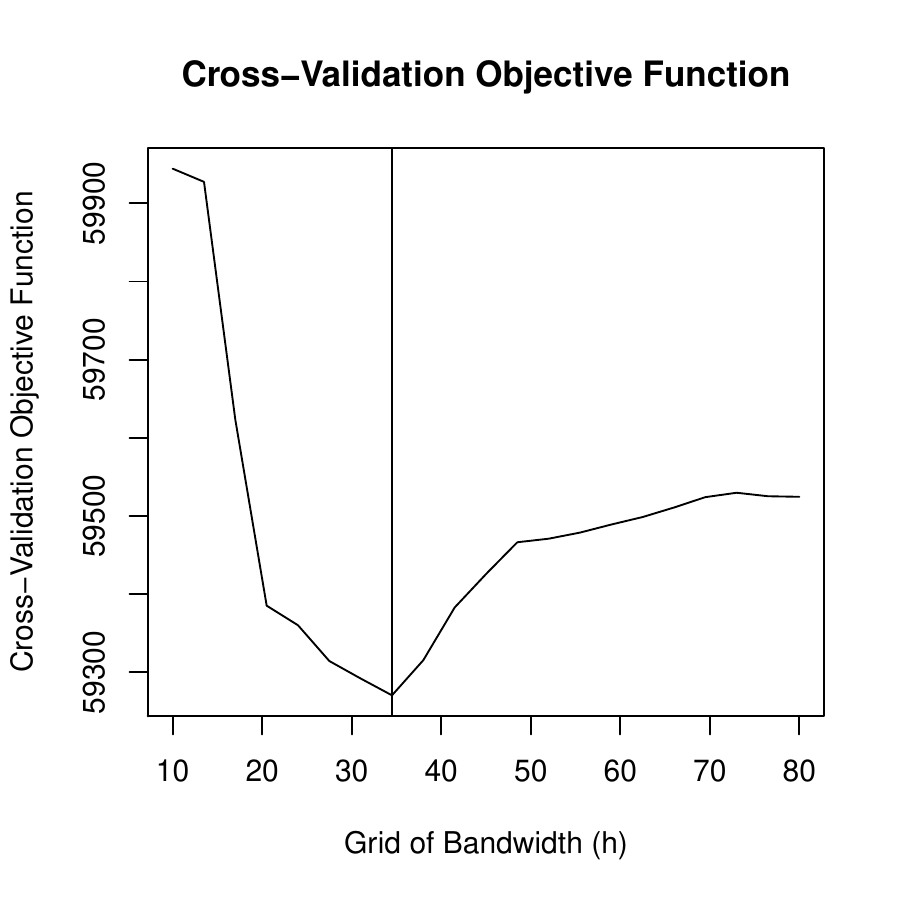

Figure 4: Values of the CV function over the selected grid.

```r
> rdbwselect(y = vote, x = margin, bwselect = "CV",
+   cvgrid_min = 10, cvgrid_max = 80, cvplot = TRUE)

Call:
rdbwselect(y = vote, x = margin, bwselect = "CV", cvgrid_min = 10,
    cvgrid_max = 80, cvplot = TRUE)

BW Selector   CV
Number of Obs 1297
NN Matches    3
Kernel Type   Triangular

                   Left Right
Number of Obs      595  702
Order Loc Poly (p) 1    1
Order Bias (q)     2    2

     h    b
   34.5 34.5
```

Figure 4 shows the CV objective function as a function of a grid of bandwidth. In this example, the cross validation approach delivers a minimum at $\hat{h}_{\mathtt{CV},p}=34.5$.

Our functions contained in the R package *rdrobust* have many other options. For instance, for the main function `rdrobust()` we have the following additional examples (output is not provided to conserve space).

- Estimation using uniform kernel:  
  `rdrobust(y = vote, x = margin, kernel = "uniform")`
- Estimation using the IK bandwidth selector:  
  `rdrobust(y = vote, x = margin, bwselect = "IK")`
- Estimation using the CV bandwidth selector:  
  `rdrobust(y = vote, x = margin, bwselect = "CV")`
- Estimation using $h_n = 15$ and $\rho = h_n/b_n = 0.8$:  
  `rdrobust(y = vote, x = margin, h = 15, rho = 0.8)`
- Estimation using $p = 2$ and $q = 4$:  
  `rdrobust(y = vote, x = margin, p = 2, q = 4)`
- Estimation using plug-in residuals estimates:  
  `rdrobust(y = vote, x = margin, vce = "resid")`

## 4 Conclusions

We introduced the main features of the R package *rdrobust*, which includes the functions `rdrobust()`, `rdbwselect()`, and `rdplot()` designed to conduct data-driven nonparametric robust inference in RD designs. This implementation covers average RD treatment effects at the cutoff in the sharp RD, sharp kink RD, fuzzy RD and fuzzy kink RD designs. A full description of this package may be found in its manual and help files. A companion Stata package offering the same structure and capabilities is described in Calonico, M. D. Cattaneo, and R. Titiunik (2014).

## 5 Acknowledgments

We thank the Editor Deepayan Sarkar, two anonymous reviewers, Richard Anderson, Devin Caughey and Marko Klašnja for comments and suggestions on previous versions of our R package *rdrobust*. The authors gratefully acknowledge financial support from the National Science Foundation (SES 1357561).

### 5.1 CRAN packages used

rdrobust

### 5.2 CRAN Task Views implied by cited packages

CausalInference, Econometrics

A. Abadie and G. W. Imbens. Large sample properties of matching estimators for average treatment effects. *Econometrica*, 74(1): 235–267, 2006.

S. Calonico, M. D. Cattaneo and M. H. Farrell. On the effect of bias estimation on coverage accuracy in nonparametric estimation. University of Michigan. 2015a.

S. Calonico, M. D. Cattaneo and R. Titiunik. Optimal data-driven regression discontinuity plots. *Journal of the American Statistical Association*, {in press}. DOI 10.1080/01621459.2015.1017578.

S. Calonico, M. D. Cattaneo and R. Titiunik. *Rdrobust: Robust data-driven statistical inference in regression-discontinuity designs.* 2015b. URL http://CRAN.R-project.org/package=rdrobust. R package version 0.80.

S. Calonico, M. D. Cattaneo and R. Titiunik. Robust nonparametric confidence intervals for regression-discontinuity designs. *Econometrica*, 82(6): 2295–2326, 2014.

D. Card, D. S. Lee, Z. Pei and A. Weber. Inference on causal effects in a generalized regression kink design. UC Berkley. 2014.

M. D. Cattaneo and M. H. Farrell. Optimal convergence rates, Bahadur representation, and asymptotic normality of partitioning estimators. *Journal of Econometrics*, 174(2): 127–143, 2013.

M. D. Cattaneo, B. Frandsen and R. Titiunik. Randomization inference in the regression discontinuity design: An application to party advantages in the U.S. Senate. *Journal of Causal Inference*, 3(1): 1–24, 2015.

J. Fan and I. Gijbels. *Local polynomial modelling and its applications.* New York: Chapman & Hall/CRC, 1996.

J. Hahn, P. Todd, and W. van der Klaauw. *Identification and estimation of treatment effects with a regression-discontinuity design.* Econometrica 69 (1):, 2001.

J. J. Heckman and E. J. Vytlacil. *Econometric evaluation of social programs, part I: Causal models, structural models and econometric policy evaluation.* In J. Heckman; E. Leamer editors Handbook ofEconometrics volume VI pages Elsevier Science B.V., 2007.

G. W. Imbens and J. M. Wooldridge. *Recent developments in the econometrics of program evaluation.* Journal of Economic Literature 47 (1):, 2009.

G. W. Imbens and K. Kalyanaraman. *Optimal bandwidth choice for the regression discontinuity estimator.* Review of Economic Studies 79 (3):, 2012.

G. Imbens and T. Lemieux. *Regression discontinuity designs: A guide to practice.* Journal of Econometrics 142 (2):, 2008.

D. S. Lee and T. Lemieux. *Regression discontinuity designs in economics.* Journal of Economic Literature 48 (2):, 2010.

D. S. Lee. *Randomized experiments from non-random selection in U.S. House elections.* Journal of Econometrics 142 (2):, 2008.

J. Porter. *Estimation in the regression discontinuity model.* Working paper University of Wisconsin, 2003.

StataCorp. *Stata data analysis statistical software: Release 13.* College Station, TX: StataCorp LP, 2013. URL http://www.stata.com/.

M. Wand and M. Jones. *Kernel Smoothing.* Chapman & Hall/CRC Florida, 1995.